# 01_Cleaning

# 1 Introduction

This script will contain the code necessary to clean the data stored in the `/RawData` folder.

To start it will focus on only cleaning data puled pertaining to the 9000 IMIS classification; then it will generate the samples pertaining to 9130 (respirable dust concentration) and 9010 (crystalline quartz fraction [%]) to calculate silica concentrations for years prior to the classification of 9000.

New variables created during the cleaning process, as well as a description of all other included variables, are contained within the excel file `DataDictionary.xlsx`.

**Goals of Cleaning:**

1. Ensure that UOM units are consistent
2. Apply inclusion/exclusion criteria
3. Add OEL data, create variable that states whether observed sample is above or below.

#IMIS 9000 data

## 1.1 Data Import and Initial Examination

```r
raw_dat <- read_delim("../RawData/Respirable_Silica_Data.txt", delim = "|")
glimpse(raw_dat)
head(raw_dat)
tail(raw_dat)
```

There are a couple of formatting tasks we need to take care of. We want to convert our data into the proper formats, and there are several variables included in the dataset that we will not need (Office, NAICS, Date_Reported, Lab_Number, CSHO).

We want to achieve the following: - Convert ‘result’ to be numeric. *Note:* some of these values are recorded as > measurement. To deal with this, we will make a new variable, `result_num` that will report whatever number is associated with the measurement. Another variable, `less_than_measurement`, will indicate whether the variable was “less than” or not.  
- Convert date to an R date format - Create a new variable that just contains the year of sample - Converting `time` to be in terms of hours, not minutes

Convert result to numeric, check how many are blanks? Also check how many are per sample type and make into nicer format. Check how many went in and used eight hour TWA calculation too. Changing time to be in terms of hours instead of minutes. Adding indicator in case of data being “less than” values, so we can go back in and perhaps do a sensitivity analysis of some kind or just have the knowledge that they were less than that number.

To start, let’s simply apply some reformats to our data. We will make this a function to save time later:

```r
clean_osha <- function(df){
  df |>
    rename_with(tolower) |>
  mutate(
    date_sampled = dmy(date_sampled),
    year = year(date_sampled),
         type = fct_recode(type,
                          "Personal" = "P",
                          "Area" = "A",
                          "Bulk" = "B",
                          "Wipe" = "W"),
    uom = fct_recode(uom,
                          "mg" = "MG", #milligrams
                          "mg" = "Y", #milligrams
                          "mcg" = "X", #micrograms
                          "mcg/m3" = "MCG/M3", #micrograms/m3
                          "mg/m3" = "MG_M3", #milligrams/m3
                          "mg/m3" = "M"), #milligrams/m3
    blank = as.logical(blank),
    time = time/60,
    less_than_measurement = grepl("^\\s*<", result),
    result_num = as.numeric(gsub("<\\s*", "", result))
    ) |>
  select(-office, -naics, -date_reported, -csho, -sic, -instrument, -blank)
}
dat <- clean_osha(raw_dat)
```

### 1.1.1 Examination

Let’s first see how many years our data spans:

```r
range(dat$date_sampled)
```

```
## [1] "2017-08-18" "2026-05-14"
```

We want to check some of these variables to see whether they are relevant to be included (i.e., contain multiple levels).

It looks like we only have NA values for instrument and blank; we can drop. We do have information for weight that may be needed.

For the unit of measurement, according to the data dictionary, M = mg/m^3, X = micrograms, Y = milligrams. We have 56 NAs which we will need to explore – it is possible it corresponds to values that contain sample weight and a result, from which we will need to complete some calculations.

Let’s check to see what the NA values correspond to before we reformat the uom variable.

```r
dat |>
  filter(is.na(uom)) |>
  select(weight, result_num, qualifier, air_volume)
```

```
## # A tibble: 56 × 4
##    weight result_num qualifier air_volume
##     <dbl>      <dbl> <chr>          <dbl>
##  1  0.124         NA <NA>            680.
##  2  0             NA <NA>             NA
##  3  0.219         NA <NA>            719.
##  4  0.068         NA <NA>            735.
##  5  0.062         NA <NA>            720.
##  6  0             NA <NA>            710.
##  7  0.096         NA <NA>            708.
##  8  0.057         NA <NA>            228.
##  9  0.199         NA <NA>            515.
## 10  0             NA <NA>             NA
## # ℹ 46 more rows
```

This is interesting, since we have measurements for weight, but we don’t know what unit the sample is in for the bulks and silica samples. We are likely unable to use these observations.

Another important aspect is that we have some units of measurement that are simply micrograms, and milligrams, without being accompanied with the air volume. Let’s check and make sure that all of these instances correspond to an air volume value. If they are all complete, we will need to look into converting the air volume (liters) to meters cubed.

```r
dat |>
  filter(uom == c("M", "MG", "X", "Y")) |>
  select(uom, air_volume) |>
  group_by(uom) |>
  summarise(
    total_rows = n(),
    non_na_values = sum(!is.na(air_volume)),
    na_count = sum(is.na(air_volume))
  )
```

```
## # A tibble: 0 × 4
## # ℹ 4 variables: uom <fct>, total_rows <int>, non_na_values <int>,
## #   na_count <int>
```

Let’s apply some reformatting again with the new information.  
M = mg/m^3, X = micrograms, Y = milligrams.

```r
dat |>
  group_by(uom) |>
  summarize(n())
```

```
## # A tibble: 5 × 2
##   uom    `n()`
##   <fct>  <int>
## 1 mg/m3    271
## 2 mcg/m3  1236
## 3 mg       266
## 4 mcg      306
## 5 <NA>      56
```

### 1.1.2 Personal Measurements

To start, we have 2,135 observations. Next, we want to see how many measurements pertain to personal measurements.

```r
dat |>
  group_by(type) |>
  summarize(n())
```

```
## # A tibble: 3 × 2
##   type     `n()`
##   <fct>    <int>
## 1 Area        20
## 2 Personal  1839
## 3 <NA>       276
```

Let’s also check to see the distribution of samples by year:

```r
dat |>
  group_by(year) |>
  summarize(count = n()) |>
  mutate(percent = (count/sum(count))*100)
```

```
## # A tibble: 10 × 3
##     year count percent
##    <dbl> <int>   <dbl>
##  1  2017    46    2.15
##  2  2018    67    3.14
##  3  2019   154    7.21
##  4  2020    89    4.17
##  5  2021   144    6.74
##  6  2022   107    5.01
##  7  2023   362   17.0
##  8  2024   541   25.3
##  9  2025   402   18.8
## 10  2026   223   10.4
```

*Note:* after excluding non-personal samples, we no longer have values that are in milligrams.

We are left with the resulting microgram observations, which do appear as though they are all lacking data on air volume.

Let’s do one last check, as it is possible that these values correspond to the time-weighted average:

```r
#TWA groupings for just instances where unit of measurement is mcg
dat |>
  filter(uom == "mcg") |>
  select(eighthr) |>
  group_by(eighthr) |>
  summarize(n())
```

```
## # A tibble: 2 × 2
##   eighthr `n()`
##   <chr>   <int>
## 1 N          62
## 2 Y         244
```

```r
dat |>
  filter(uom =="mcg" & eighthr == "N") |>
  group_by(qualifier) |>
  summarize(n())
```

```
## # A tibble: 2 × 2
##   qualifier `n()`
##   <chr>     <int>
## 1 ND            1
## 2 ND-BLK       61
```

```r
dat |>
  filter(uom =="mcg" & eighthr == "N") |>
  group_by(air_volume) |>
  summarise(
    total_rows = n(),
    non_na_values = sum(!is.na(air_volume)),
    na_count = sum(is.na(air_volume))
  )
```

```
## # A tibble: 1 × 4
##   air_volume total_rows non_na_values na_count
##        <dbl>      <int>         <int>    <int>
## 1         NA         62             0       62
```

```r
dat |>
  filter(uom =="mcg" & eighthr == "N") |>
  select(result_num) |>
  summary()
```

```
##    result_num
##  Min.   :0
##  1st Qu.:0
##  Median :0
##  Mean   :0
##  3rd Qu.:0
##  Max.   :0
```

```r
dat |>
  filter(uom =="mcg" & eighthr == "Y") |>
  select(result_num) |>
  summary()
```

```
##    result_num
##  Min.   : 0.0000
##  1st Qu.: 0.0000
##  Median : 0.0000
##  Mean   : 0.0418
##  3rd Qu.: 0.0000
##  Max.   :10.2000
```

Ok, we have figured out what happened –> specifically the measurements that aren’t standardized to volume all contains results less than the quantification limit or are blank.

Next, we want to scrutinize our observations that are a time-weighted average and are coded as “mcg” for the unit. Let’s see what these measurements actually are:

```r
mcg_time_weighted <- dat |>
  filter(uom =="mcg" & eighthr == "Y")

mcg_time_weighted |>
  select(result_num) |>
  summary()
```

```
##    result_num
##  Min.   : 0.0000
##  1st Qu.: 0.0000
##  Median : 0.0000
##  Mean   : 0.0418
##  3rd Qu.: 0.0000
##  Max.   :10.2000
```

```r
#comparing to summary of observations that aren't time-weighted and are coded as "mcg/m3" -- 491 observations
dat |>
  filter(uom == "mcg/m3" & eighthr == "N") |>
  select(result_num) |>
  summary()
```

```
##    result_num
##  Min.   :   0.00
##  1st Qu.:   0.00
##  Median :   0.00
##  Mean   :  85.05
##  3rd Qu.:  47.60
##  Max.   :4110.00
```

```r
#comparing to those that ARE time-weighted and coded as "mcg/m3" -- 737 observations
dat |>
  filter(uom == "mcg/m3" & eighthr == "Y") |>
  select(result_num) |>
  summary()
```

```
##    result_num
##  Min.   :   0.0
##  1st Qu.:   0.0
##  Median :  22.2
##  Mean   : 126.7
##  3rd Qu.:  69.1
##  Max.   :5093.0
```

We want to go further, tracking if there are overlapping sampling numbers appear across these groups:

```r
mcg_tw    <- dat |> filter(uom == "mcg" & eighthr == "Y")     |> mutate(group = "mcg_TW")
m3_no_tw  <- dat |> filter(uom == "mcg/m3" & eighthr == "N")  |> mutate(group = "m3_notTW")
m3_tw     <- dat |> filter(uom == "mcg/m3" & eighthr == "Y")  |> mutate(group = "m3_TW")

all_three <- bind_rows(mcg_tw, m3_no_tw, m3_tw)

# How many SAMPLING_NUMBERs appear in more than one group?
overlap_check <- all_three |>
  group_by(sampling_number) |>
  summarise(
    n_obs = n(),
    n_field_numbers = n_distinct(field_number),
    n_groups = n_distinct(group),
    groups_present = paste(sort(unique(group)), collapse = ", "),
    .groups = "drop"
  ) |>
  filter(n_groups > 1)

overlap_check
```

```
## # A tibble: 212 × 5
##    sampling_number n_obs n_field_numbers n_groups groups_present
##    <chr>           <int>           <int>    <int> <chr>
##  1 374920              2               2        2 m3_TW, mcg_TW
##  2 376325              2               2        2 m3_TW, mcg_TW
##  3 377547              2               2        2 m3_TW, mcg_TW
##  4 385245              2               2        2 m3_TW, mcg_TW
##  5 404284              3               3        2 m3_TW, mcg_TW
##  6 404289              3               3        2 m3_TW, mcg_TW
##  7 416220              4               2        2 m3_TW, mcg_TW
##  8 416221              4               2        2 m3_TW, mcg_TW
##  9 416548              4               2        2 m3_TW, mcg_TW
## 10 423655              6               3        2 m3_TW, mcg_TW
## # ℹ 202 more rows
```

```r
all_three |>
  arrange(sampling_number, field_number) |>
  select(sampling_number, field_number, uom, eighthr, result_num, group) |>
  filter(sampling_number %in% overlap_check$sampling_number)
```

```
## # A tibble: 515 × 6
##    sampling_number field_number uom    eighthr result_num group
##    <chr>           <chr>        <fct>  <chr>        <dbl> <chr>
##  1 374920          07009E       mcg/m3 Y              749 m3_TW
##  2 374920          07632E       mcg    Y                0 mcg_TW
##  3 376325          01241D       mcg    Y                0 mcg_TW
##  4 376325          01488D       mcg/m3 Y                0 m3_TW
##  5 377547          05890D       mcg/m3 Y              476 m3_TW
##  6 377547          Y5571        mcg    Y                0 mcg_TW
##  7 385245          01280D       mcg    Y                0 mcg_TW
##  8 385245          08093D       mcg/m3 Y              604 m3_TW
##  9 404284          02523D       mcg    Y                0 mcg_TW
## 10 404284          02530D       mcg/m3 Y                0 m3_TW
## # ℹ 505 more rows
```

```r
all_three |>
  group_by(field_number) |>
  summarise(
    n_obs = n(),
    n_groups = n_distinct(group),
    .groups = "drop"
  ) |>
  filter(n_groups > 1)
```

```
## # A tibble: 0 × 3
## # ℹ 3 variables: field_number <chr>, n_obs <int>, n_groups <int>
```

How many sampling numbers have TWA record:

```r
# does this SAMPLING_NUMBER have an eighthr == "Y" record at all (regardless of uom)?
twa_lookup <- dat |>
  group_by(sampling_number) |>
  summarise(
    has_twa = any(eighthr == "Y"),
    n_twa_records = sum(eighthr == "Y"),
    n_component_records = sum(eighthr == "N"),
    .groups = "drop"
  )

twa_lookup |> count(has_twa, n_twa_records)
```

```
## # A tibble: 9 × 3
##   has_twa n_twa_records     n
##   <lgl>           <int> <int>
## 1 FALSE               0   349
## 2 TRUE                1   333
## 3 TRUE                2   287
## 4 TRUE                3    37
## 5 TRUE                4    33
## 6 TRUE                5     1
## 7 TRUE                6     5
## 8 TRUE               NA    63
## 9 NA                 NA    55
```

Join back into records to see which are “covered” by a time weighted average:

```r
mcg_components <- dat |>
  filter(uom == "mcg" & eighthr == "N") |>
  left_join(twa_lookup, by = "sampling_number")

# how many of these component records belong to a sampling number that DOES have a TWA?
mcg_components |>
  count(has_twa)
```

```
## # A tibble: 1 × 2
##   has_twa     n
##   <lgl>   <int>
## 1 FALSE      62
```

Looking at multiple TWA samples

```r
dat |>
  filter(eighthr == "Y") |>
  group_by(sampling_number) |>
  filter(n() > 1) |>
  select(sampling_number, field_number, uom, result_num, time) |>
  arrange(sampling_number) |>
  print(n = 30)
```

```
## # A tibble: 872 × 5
## # Groups:   sampling_number [371]
##    sampling_number field_number uom    result_num  time
##    <chr>           <chr>        <fct>       <dbl> <dbl>
##  1 306812          9130A        mcg/m3        0   NA
##  2 306812          8559A        mcg/m3        0    8.08
##  3 315692          2218A        mcg/m3        0    7.57
##  4 315692          8631A        mcg/m3        0   NA
##  5 325663          03289D       mcg/m3      195    2.43
##  6 325663          02857D       mcg/m3      948    4.92
##  7 325665          03294D       mcg/m3      993    5
##  8 325665          03305D       mcg/m3      227    2.42
##  9 325669          03283D       mcg/m3      947    4.92
## 10 325669          02832D       mcg/m3        0    2.42
## 11 325676          03273D       mcg/m3        0   NA
```

[output cut: 20 more lines]

```r
#check for 8-hr calculation:
check_calc_status <- dat |>
  filter(eighthr == "Y" & uom == "mcg/m3") |>
  group_by(sampling_number) |>
  summarise(
    n_components = n(),
    n_distinct_results = n_distinct(result_num),
    all_results_identical = n_distinct(result_num) == 1,
    total_time = sum(time, na.rm = TRUE),
    .groups = "drop"
  )

# Summary: how many sampling numbers have identical vs differing result_num across components?
check_calc_status |>
  filter(n_components > 1) |>   # only relevant for sampling numbers with multiple media
  count(all_results_identical)
```

```
## # A tibble: 2 × 2
##   all_results_identical     n
##   <lgl>                 <int>
## 1 FALSE                    62
## 2 TRUE                     89
```

```r
# For sampling numbers with >1 component, does a duration-weighted average of the
# individual result_num values recreate any single one of them, or land somewhere in between?
check_calc_status_detail <- dat |>
  filter(eighthr == "Y" & uom == "mcg/m3") |>
  group_by(sampling_number) |>
  filter(n() > 1) |>
  summarise(
    results = paste(round(result_num, 1), collapse = ", "),
    times = paste(round(time, 2), collapse = ", "),
    computed_twa = sum(result_num * time, na.rm = TRUE) / sum(time, na.rm = TRUE),
    .groups = "drop"
  )

check_calc_status_detail
```

```
## # A tibble: 151 × 4
##    sampling_number results       times          computed_twa
##    <chr>           <chr>         <chr>                 <dbl>
##  1 306812          0, 0          NA, 8.08                0
##  2 315692          0, 0          7.57, NA                0
##  3 325663          195, 948      2.43, 4.92            699.
##  4 325665          993, 227      5, 2.42               743.
##  5 325669          947, 0        4.92, 2.42            635.
##  6 325676          0, 274, 0     NA, 5, 2.28           188.
##  7 332668          0, 0          NA, 7.73                0
##  8 333357          1133, 1550, 0 4.67, 2.25, NA       1269.
##  9 333410          242.2, 0      4.83, NA              242.
## 10 335204          44.2, 0       7.08, NA               44.2
## # ℹ 141 more rows
```

```r
check_calc_status2 <- dat |>
  filter(eighthr == "Y" & uom == "mcg/m3") |>
  group_by(sampling_number) |>
  summarise(
    n_components = n(),
    n_distinct_results = n_distinct(result_num),
    all_results_identical = n_distinct(result_num) == 1,
    all_results_zero = all(result_num == 0),
    total_time = sum(time, na.rm = TRUE),
    .groups = "drop"
  )

# Break the "identical" bucket into trivial-zero vs genuine non-zero matches
check_calc_status2 |>
  filter(n_components > 1) |>
  count(all_results_identical, all_results_zero)
```

```
## # A tibble: 3 × 3
##   all_results_identical all_results_zero     n
##   <lgl>                 <lgl>            <int>
## 1 FALSE                 FALSE               62
## 2 TRUE                  FALSE               33
## 3 TRUE                  TRUE                56
```

### 1.1.3 Time-weighted average observations

Next, we want to get an idea of how our samples may differ depending on how many of them used a time-weighted average.

```r
dat |>
  group_by(eighthr) |>
  summarize(n())
```

```
## # A tibble: 4 × 2
##   eighthr           `n()`
##   <chr>             <int>
## 1 N                   734
## 2 STEL CEILING PEAK     8
## 3 Y                  1260
## 4 <NA>                133
```

```r
dat |>
  filter(eighthr == "STEL CEILING PEAK") |>
  select(everything())  # STEL information
```

```
## # A tibble: 8 × 19
##   inspection sampling_number establishment date_sampled eighthr       lab_number
##        <dbl> <chr>           <chr>         <date>       <chr>         <chr>
## 1    1863156 484899-OIS      GRANITE USA   2025-12-17   STEL CEILING… 56964
## 2    1863156 484896-OIS      GRANITE USA   2025-12-17   STEL CEILING… 56962
## 3    1863156 484899-OIS      GRANITE USA   2025-12-17   STEL CEILING… 56965
## 4    1863156 484900-OIS      GRANITE USA   2025-12-17   STEL CEILING… 56966
## 5    1863156 484900-OIS      GRANITE USA   2025-12-17   STEL CEILING… 56967
## 6    1863156 484896-OIS      GRANITE USA   2025-12-17   STEL CEILING… 56961
## 7    1863156 484901-OIS      GRANITE USA   2025-12-17   STEL CEILING… 56969
## 8    1863156 484901-OIS      GRANITE USA   2025-12-17   STEL CEILING… 56968
## # ℹ 13 more variables: field_number <chr>, type <fct>, time <dbl>,
## #   air_volume <dbl>, weight <dbl>, imis <dbl>, substance <chr>, result <chr>,
## #   uom <fct>, qualifier <chr>, year <dbl>, less_than_measurement <lgl>,
## #   result_num <dbl>
```

```r
#examining time distribution by the time-weighted data:
dat |>
  group_by(eighthr) |>
  summarise(
    count = n(),
    mean = mean(result_num, na.rm = TRUE),
    median = median(result_num, na.rm = TRUE),
    min = min(result_num, na.rm = TRUE),
    max = max(result_num, na.rm = TRUE),
    sd = sd(result_num, na.rm = TRUE)
  )
```

```
## # A tibble: 4 × 7
##   eighthr           count    mean median    min      max        sd
##   <chr>             <int>   <dbl>  <dbl>  <dbl>    <dbl>     <dbl>
## 1 N                   734 61.3    0.0126 0      4110     300.
## 2 STEL CEILING PEAK     8  0.102  0.0988 0.0302    0.195   0.0517
## 3 Y                  1260 76.3    0.01   0      5093     358.
## 4 <NA>                133  0.0104 0.01   0.01      0.02    0.00198
```

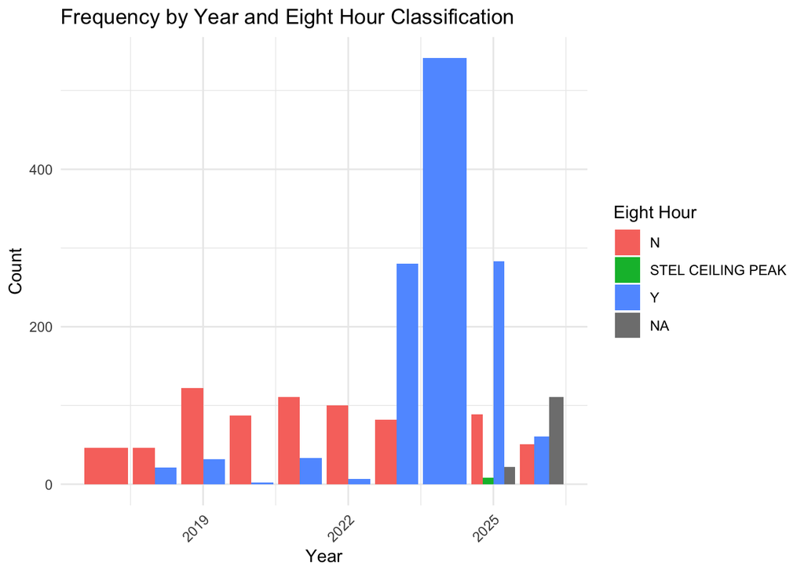

```r
#is there a time-trend component to the data that are missing time-weighting?
dat |>
  group_by(year, eighthr) |>
  summarize(count = n(), .groups = 'drop') |>
  ggplot(aes(x = year, y = count, fill = eighthr)) +
  geom_col(position = "dodge") +
  labs(title = "Frequency by Year and Eight Hour Classification",
       x = "Year",
       y = "Count",
       fill = "Eight Hour") +
  theme_minimal() +
  theme(axis.text.x = element_text(angle = 45, hjust = 1))
```

Looks like we will not be retaining any of the results corresponding to the STEL ceiling peak as they have way too short times of duration.

### 1.1.4 Over 6-hours of duration

Let’s create an indicator variable for whether the measurements were above 6-hours or not, and take a peek at what data remains:

```r
dat |>
  filter(eighthr == "Y") |>
  count()
```

```
## # A tibble: 1 × 1
##       n
##   <int>
## 1  1260
```

```r
dat |>
  filter(eighthr == "Y") |>
  count()
```

```
## # A tibble: 1 × 1
##       n
##   <int>
## 1  1260
```

```r
dat |>
  filter(eighthr == "N" & time >=6) |>
  count()
```

```
## # A tibble: 1 × 1
##       n
##   <int>
## 1   275
```

```r
dat |>
  filter(eighthr == "N" & is.na(time) ) |>
  count()
```

```
## # A tibble: 1 × 1
##       n
##   <int>
## 1   134
```

```r
dat |>
  filter(eighthr == "N" & time <6) |>
  count()
```

```
## # A tibble: 1 × 1
##       n
##   <int>
## 1   325
```

Before we exclude any data, we want to check if we have repeated measurements per establishments:

```r
 full_sample_check <- dat |>
  group_by(establishment) |>
  summarise(
    n_obs = n(),
    n_years = n_distinct(year),
    .groups = 'drop'
  )

# Summary stats
full_sample_check |>
  summarise(
    total_establishments = n(),
    mean_obs_per_est = mean(n_obs),
    median_obs_per_est = median(n_obs),
    est_with_5plus = sum(n_obs >= 5),
    est_with_10plus = sum(n_obs >= 10),
    pct_5plus = round(100 * sum(n_obs >= 5) / n(), 1),
    pct_10plus = round(100 * sum(n_obs >= 10) / n(), 1)
  )
```

```
## # A tibble: 1 × 7
##   total_establishments mean_obs_per_est median_obs_per_est est_with_5plus
##                  <int>            <dbl>              <int>          <int>
## 1                  393             5.43                  4            191
## # ℹ 3 more variables: est_with_10plus <int>, pct_5plus <dbl>, pct_10plus <dbl>
```

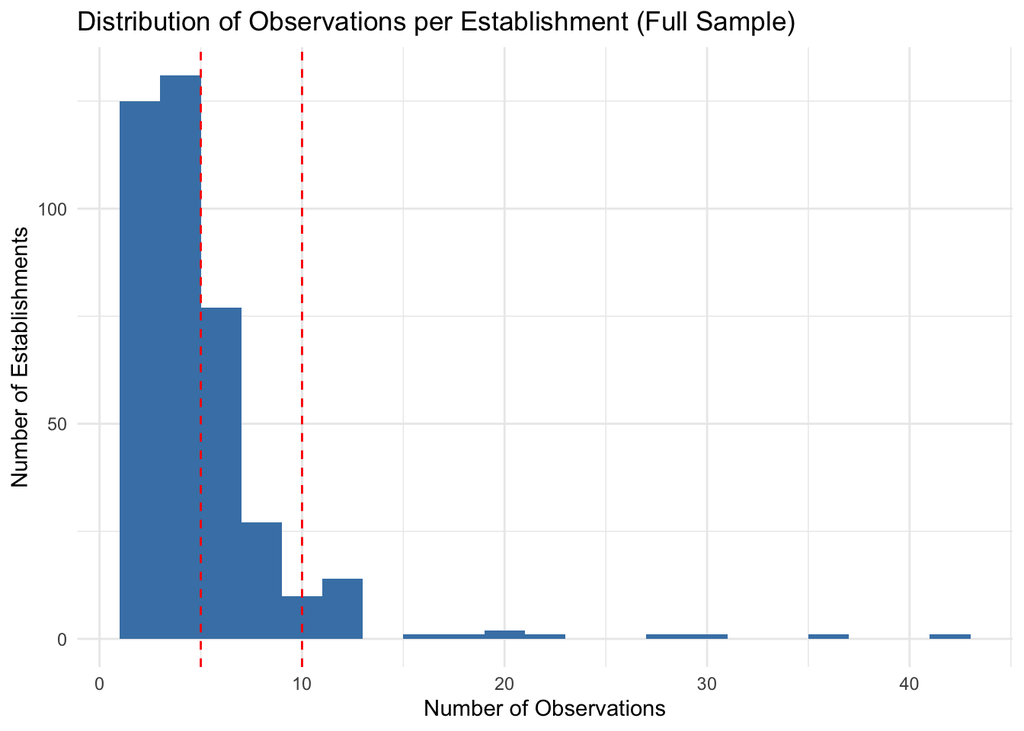

```r
# Distribution
full_sample_check |>
  ggplot(aes(x = n_obs)) +
  geom_histogram(binwidth = 2, fill = "steelblue") +
  geom_vline(xintercept = c(5, 10), linetype = "dashed", color = "red") +
  labs(title = "Distribution of Observations per Establishment (Full Sample)",
       x = "Number of Observations",
       y = "Number of Establishments") +
  theme_minimal()
```

```r
#Restricted sample:
restricted_sample_check <- dat |>
  filter(time >= 6) |>  # or your > 6 hour filter
  group_by(establishment) |>
  summarise(
    n_obs = n(),
    n_years = n_distinct(year),
    .groups = 'drop'
  )

restricted_sample_check |>
  summarise(
    total_establishments = n(),
    mean_obs_per_est = mean(n_obs),
    median_obs_per_est = median(n_obs),
    est_with_5plus = sum(n_obs >= 5),
    est_with_10plus = sum(n_obs >= 10),
    pct_5plus = round(100 * sum(n_obs >= 5) / n(), 1),
    pct_10plus = round(100 * sum(n_obs >= 10) / n(), 1)
  )
```

```
## # A tibble: 1 × 7
##   total_establishments mean_obs_per_est median_obs_per_est est_with_5plus
##                  <int>            <dbl>              <dbl>          <int>
## 1                  208             3.08                  3             32
## # ℹ 3 more variables: est_with_10plus <int>, pct_5plus <dbl>, pct_10plus <dbl>
```

```r
#summary table
tribble(
  ~criterion, ~guideline, ~full_sample, ~restricted_sample,
  "Number of establishments", "≥20-30", nrow(full_sample_check), nrow(restricted_sample_check),
  "% with 5+ observations", "~80%+",
  round(100 * sum(full_sample_check$n_obs >= 5) / nrow(full_sample_check), 1),
  round(100 * sum(restricted_sample_check$n_obs >= 5) / nrow(restricted_sample_check), 1),
  "% with 10+ observations", "~50%+",
  round(100 * sum(full_sample_check$n_obs >= 10) / nrow(full_sample_check), 1),
  round(100 * sum(restricted_sample_check$n_obs >= 10) / nrow(restricted_sample_check), 1)
)
```

```
## # A tibble: 3 × 4
##   criterion                guideline full_sample restricted_sample
##   <chr>                    <chr>           <dbl>             <dbl>
## 1 Number of establishments ≥20-30          393               208
## 2 % with 5+ observations   ~80%+            48.6              15.4
## 3 % with 10+ observations  ~50%+             8.4               1
```

We do not meet the assumptions of LMEM according to [this article](https://ladal.edu.au/tutorials/mixedmodel/mixedmodel.html), which details that we need 5-10 observations per random-effect level for reliable variance estimates, and at least 20-30 random-effect levels.

It is recommended that no matter what, we apply cluster-robust standard errors to account for within-group variation. To deal with this, we are going to plan on fitting a generalized linear mixed model that adds a cluster-specific random effect to the linear predictor. Our cluster variable will be id.

## 1.2 Unit of Measurement Consistency

We need to make sure we are only using reported results under one standard unit of measurement.

Since the OSHA limits correspond to micrograms/m^3, we will convert our other measurement to be consistent with this.

Just to review, let’s double-check what the possible values are for our silica measurements:

```r
dat |>
  group_by(uom) |>
  summarize(n())
```

```
## # A tibble: 5 × 2
##   uom    `n()`
##   <fct>  <int>
## 1 mg/m3    271
## 2 mcg/m3  1236
## 3 mg       266
## 4 mcg      306
## 5 <NA>      56
```

We have 56 that are NA, let’s just double check that these aren’t all time-weighted before we consider deleting them:

```r
dat |>
  filter(is.na(uom)) |>
  group_by(eighthr) |>
  summarize(n())
```

```
## # A tibble: 2 × 2
##   eighthr `n()`
##   <chr>   <int>
## 1 N          39
## 2 Y          17
```

There are 39 observations that are not time-weighted, so we need to be sure to exclude them from the sample. We are also going to plan on doing a sensitivity analysis on the observations that have no uom but are time-weighted; we cannot be sure what units these are in, so we can add them back in later and see whether things change significantly.

### 1.2.1 Comparing mg to mcg

Before we convert all our units, let’s do a check to see how the different concentrations differ:

```r
dat |>
  group_by(uom) |>
  summarize(n= n(),
            mean = mean(result_num),
            sd = sd(result_num))
```

```
## # A tibble: 5 × 4
##   uom        n     mean        sd
##   <fct>  <int>    <dbl>     <dbl>
## 1 mg/m3    271  NA       NA
## 2 mcg/m3  1236 110.     417.
## 3 mg       266   0.0106   0.00231
## 4 mcg      306   0.0333   0.583
## 5 <NA>      56  NA       NA
```

Looks like we need to see how many observations are missing data for the mg/m3 observations:

```r
dat |>
  filter(uom == "mg/m3") |>
  summarize(n = sum(is.na(result_num)))
```

```
## # A tibble: 1 × 1
##       n
##   <int>
## 1    29
```

```r
dat |>
  filter(uom == "mg/m3" ) |>
  group_by(qualifier) |>
  summarize(n())
```

```
## # A tibble: 1 × 2
##   qualifier `n()`
##   <chr>     <int>
## 1 <NA>        271
```

## 1.3 Establishment standardization

Now that we have our datasets for respirable silica and our calculated versions, we need to prepare for the merge by deleting duplicate entries. We have some duplicates that are the same field and lab number, due to different spellings of the establishment.

We are going to make a function that resolves duplicate lab_number + field_number entries caused by inconsistent spelling.

```r
standardize_establishment <- function(x) {
  x |>
    str_squish() |>                          # trim + collapse internal whitespace
    str_to_upper() |>
    str_replace_all("&", "AND") |>           # unify ampersand vs "AND"
    str_replace_all("[[:punct:]]", "") |>    # strip periods, commas, hyphens, etc.
    str_squish()                             # re-squish in case punctuation removal left double spaces
}


dat <- dat |> mutate(establishment = standardize_establishment(establishment))
```

## 1.4 Inclusion/Exclusion

To begin, let’s see how many observations we have:

```r
nrow(dat)
```

```
## [1] 2135
```

We are starting with 2,135.

### 1.4.1 Correct Measurement

We need our data to record a legitimate recorded measurement. First, we will check to see what the samples are recorded as when they are listed as being LOQ:

```r
dat |>
  summarise(sum(is.na(result_num)))
```

```
## # A tibble: 1 × 1
##   `sum(is.na(result_num))`
##                      <int>
## 1                       85
```

```r
dat |>
  filter(is.na(result_num)) |>
  group_by(qualifier) |>
  summarise(n())
```

```
## # A tibble: 1 × 2
##   qualifier `n()`
##   <chr>     <int>
## 1 <NA>         85
```

There are 85 observations that are missing data for the recorded measurement. As such we will have to delete these observations.

```r
dat2 <- dat |>
  filter(!is.na(result_num))
```

After removal, we now have 2,050 observations.

### 1.4.2 Removing samples lacking concentration data

We are only going to retain samples that contain clear units standardized to air volume. We cannot convert our observations to a concentration that are standalones, since they lack air volume data.

To our best knowledge, the records cannot be personal air samples, and were likely bulk samples that were miscoded as personal samples.

```r
dat3 <- dat2 |>
    mutate(
    result_num = case_when(
      uom == "mg" ~ result_num * 1000,      # mg → mcg (multiply by 1000)
      uom == "mg/m3" ~ result_num * 1000,   # mg/m3 → mcg/m3 (multiply by 1000)
      TRUE ~ result_num
    ),
    uom = case_when(
      uom == "mg" ~ "mcg",
      uom == "mg/m3" ~ "mcg/m3",
      TRUE ~ uom
    )
  )

dat3 |>
  group_by(uom) |>
  summarise(n())
```

```
## # A tibble: 2 × 2
##   uom    `n()`
##   <chr>  <int>
## 1 mcg      572
## 2 mcg/m3  1478
```

At this time, there are 572 measurements that are not in concentration form. We will exclude:

```r
dat3 <- dat3 |>
  filter(uom == "mcg/m3")
```

```r
dat3 <- dat3 |>
  mutate(silica_conc = result_num)
```

### 1.4.3 No blank samples

Next we will exclude all samples that were recorded as blank.

```r
dat3 |>
  group_by(qualifier) |>
  count()
```

```
## # A tibble: 9 × 2
## # Groups:   qualifier [9]
##   qualifier      n
##   <chr>      <int>
## 1 "<="           8
## 2 "<=\t"         1
## 3 "=<"           1
## 4 "@"           13
## 5 "ND"         463
## 6 "ND\t"        16
## 7 "ND-BLK"      71
## 8 "ND-BLK\t"     3
## 9  <NA>        902
```

```r
dat4 <- dat3 |>
  filter(!(qualifier %in% c("BLK","ND-BLK", "ND-BLK/t")))
```

### 1.4.4 No duplicate samples

We need to ensure that we don’t have duplicate samples in the data.

```r
nrow(dat4) #how many rows in data?
```

```
## [1] 1407
```

```r
#look at duplicates
dat4_duplicates <- dat4 |>
  group_by(lab_number, field_number, silica_conc, date_sampled) |>
  filter(n() > 1) |>
  ungroup()

dat4_duplicates |>
  select(lab_number, field_number, date_sampled, establishment, silica_conc) |>
  head()
```

```
## # A tibble: 6 × 5
##   lab_number field_number date_sampled establishment                 silica_conc
##   <chr>      <chr>        <date>       <chr>                               <dbl>
## 1 F30195     01581D       2023-11-02   OZARK MOUNTAIN GRANITE AND T…       214
## 2 F30196     08368D       2023-11-02   OZARK MOUNTAIN GRANITE AND T…        43.9
## 3 F30195     01581D       2023-11-02   OZARK MOUNTAIN GRANITE AND T…       214
## 4 F30196     08368D       2023-11-02   OZARK MOUNTAIN GRANITE AND T…        43.9
## 5 F30067     07870E       2023-11-01   W C CANNIFF AND SONS INC              0
## 6 F30067     07870E       2023-11-01   WC CANNIFF AND SONS INC               0
```

```r
#all variables
dat4_duplicates |>
  head()
```

```
## # A tibble: 6 × 20
##   inspection sampling_number establishment       date_sampled eighthr lab_number
##        <dbl> <chr>           <chr>               <date>       <chr>   <chr>
## 1    1690207 433379          OZARK MOUNTAIN GRA… 2023-11-02   Y       F30195
## 2    1690207 433380          OZARK MOUNTAIN GRA… 2023-11-02   Y       F30196
## 3    1690207 433379          OZARK MOUNTAIN GRA… 2023-11-02   Y       F30195
## 4    1690207 433380          OZARK MOUNTAIN GRA… 2023-11-02   Y       F30196
## 5    1694359 433269          W C CANNIFF AND SO… 2023-11-01   Y       F30067
## 6    1694359 433269          WC CANNIFF AND SON… 2023-11-01   Y       F30067
## # ℹ 14 more variables: field_number <chr>, type <fct>, time <dbl>,
## #   air_volume <dbl>, weight <dbl>, imis <dbl>, substance <chr>, result <chr>,
## #   uom <chr>, qualifier <chr>, year <dbl>, less_than_measurement <lgl>,
## #   result_num <dbl>, silica_conc <dbl>
```

```r
dat4_dedup <- dat4|>
  distinct(lab_number, field_number, silica_conc, date_sampled,
           .keep_all = TRUE)

nrow(dat4_dedup) #how many rows are left after deleting duplicates?
```

```
## [1] 1308
```

### 1.4.5 Only Personal Measurements

We only want to retain personal measurements for this analysis:

```r
dat4_dedup |>
  group_by(type) |>
  count()
```

```
## # A tibble: 2 × 2
## # Groups:   type [2]
##   type         n
##   <fct>    <int>
## 1 Area         9
## 2 Personal  1299
```

```r
dat5 <- dat4_dedup |>
  filter(type == "Personal")
```

We are left with 1,299 observations.

### 1.4.6 >= 6 hrs

We need to ensure that we have measurements that were taken over 6 hours in length:

```r
dat5 |>
  mutate(six_hours = time >= 6) |>
  filter(six_hours == "TRUE") |>
  group_by( year) |>
  summarise(n()) #checking that we have enough observations
```

```
## # A tibble: 10 × 2
##     year `n()`
##    <dbl> <int>
##  1  2017    11
##  2  2018    31
##  3  2019    40
##  4  2020    34
##  5  2021    32
##  6  2022    48
##  7  2023    65
##  8  2024   164
##  9  2025    92
## 10  2026    44
```

```r
dat5 |>
  filter(is.na(time)) |>
  count()
```

```
## # A tibble: 1 × 1
##       n
##   <int>
## 1     5
```

```r
dat5 |>
  filter(time < 6) |>
  count()
```

```
## # A tibble: 1 × 1
##       n
##   <int>
## 1   733
```

```r
dat5 |>
  filter(time < 6 & is.na(time)) |>
  count()
```

```
## # A tibble: 1 × 1
##       n
##   <int>
## 1     0
```

```r
dat6 <- dat5 |>
  filter(!(time < 6 & !is.na(time)))
```

Let’s check and see how many observations we have:

```r
glimpse(dat6)
```

```
## Rows: 566
## Columns: 20
## $ inspection            <dbl> 1892548, 1892548, 1892548, 1875265, 1875265, 188…
## $ sampling_number       <chr> "494572-OIS", "494575-OIS", "494578-OIS", "49223…
## $ establishment         <chr> "DELPHOS GRANITE WORKS INC", "DELPHOS GRANITE WO…
## $ date_sampled          <date> 2026-05-14, 2026-05-14, 2026-05-14, 2026-04-16,…
## $ eighthr               <chr> "N", "N", "N", "Y", "Y", "N", "N", "N", "N", "N"…
## $ lab_number            <chr> "65868", "65871", "65872", "64207", "64209", "63…
## $ field_number          <chr> "00775F", "00641F", "00235F", "04715D", "01043H"…
## $ type                  <fct> Personal, Personal, Personal, Personal, Personal…
## $ time                  <dbl> 7.983333, 7.233333, 7.150000, 6.500000, 6.500000…
## $ air_volume            <dbl> 785.5600, 720.4400, 707.8500, 659.1000, 663.0000…
## $ weight                <dbl> NA, NA, NA, NA, NA, NA, NA, NA, NA, NA, NA, NA, …
## $ imis                  <dbl> 9000, 9000, 9000, 9000, 9000, 9000, 9000, 9000, …
## $ substance             <chr> "SILICA, RESPIRABLE CRYSTALLINE (NEW)", "SILICA,…
## $ result                <chr> "< 0.0127", "< 0.0139", "< 0.0141", "0.25", "0.2…
## $ uom                   <chr> "mcg/m3", "mcg/m3", "mcg/m3", "mcg/m3", "mcg/m3"…
## $ qualifier             <chr> NA, NA, NA, NA, NA, NA, NA, NA, NA, NA, NA, NA, …
## $ year                  <dbl> 2026, 2026, 2026, 2026, 2026, 2026, 2026, 2026, …
## $ less_than_measurement <lgl> TRUE, TRUE, TRUE, FALSE, FALSE, TRUE, FALSE, TRU…
## $ result_num            <dbl> 12.7, 13.9, 14.1, 250.0, 214.0, 25.7, 25.3, 25.7…
## $ silica_conc           <dbl> 12.7, 13.9, 14.1, 250.0, 214.0, 25.7, 25.3, 25.7…
```

Let’s clean up our data too, only retaining the variables we need:

```r
dat7 <- dat6 |>
  select(sampling_number, establishment, date_sampled, lab_number, field_number, time, imis, year, silica_conc)
```

# 2 IMIS 9130 and 9010 Data Import

Next, we need to import the data pertaining to the other two codes. We need to be certain that the samples match with each other (matching on “Lab No.”), before multiplying the respirable dust concentration by the quartz percentage for corresponding samples.

```r
dust_dat <- read_delim("../RawData/Respirable_Dust_Concentration.txt", delim = "|")
glimpse(dust_dat)
```

```
## Rows: 3,893
## Columns: 23
## $ INSPECTION      <dbl> 1892548, 1892548, 1892548, 1892548, 1892548, 1892548, …
## $ SAMPLING_NUMBER <chr> "494572-OIS", "494575-OIS", "494578-OIS", "494579-OIS"…
## $ OFFICE          <dbl> 524700, 524700, 524700, 524700, 524700, 524700, 524700…
## $ ESTABLISHMENT   <chr> "DELPHOS GRANITE WORKS INC", "DELPHOS GRANITE WORKS IN…
## $ SIC             <dbl> NA, NA, NA, NA, NA, NA, NA, NA, NA, NA, NA, NA, NA, NA…
## $ NAICS           <dbl> 327991, 327991, 327991, 327991, 327991, 327991, 327991…
## $ CSHO            <lgl> NA, NA, NA, NA, NA, NA, NA, NA, NA, NA, NA, NA, NA, NA…
## $ DATE_SAMPLED    <chr> "14-MAY-26", "14-MAY-26", "14-MAY-26", "14-MAY-26", "1…
## $ DATE_REPORTED   <chr> "05-JUN-26", "05-JUN-26", "05-JUN-26", "05-JUN-26", "0…
## $ EIGHTHR         <chr> "N", "N", "N", NA, NA, NA, NA, NA, "Y", "Y", NA, NA, N…
## $ INSTRUMENT      <chr> NA, NA, NA, NA, NA, NA, NA, NA, NA, NA, NA, NA, NA, NA…
## $ LAB_NUMBER      <chr> "65868", "65871", "65872", "65869", "65869", "65869", …
## $ FIELD_NUMBER    <chr> "00775F", "00641F", "00235F", "00718F", "00718F", "007…
## $ TYPE            <chr> "P", "P", "P", NA, NA, NA, NA, NA, "P", "P", NA, NA, N…
## $ BLANK           <chr> "N", "N", "N", "Y", "Y", "Y", "Y", "Y", "N", "N", "Y",…
## $ TIME            <dbl> 479, 434, 429, NA, NA, NA, NA, NA, 390, 390, NA, NA, N…
## $ AIR_VOLUME      <dbl> 785.5600, 720.4400, 707.8500, NA, NA, NA, NA, NA, 659.…
## $ WEIGHT          <dbl> NA, NA, NA, NA, NA, NA, NA, NA, NA, NA, NA, NA, NA, NA…
## $ IMIS            <dbl> 9130, 9130, 9130, 9130, 9130, 9130, 9130, 9130, 9130, …
## $ SUBSTANCE       <chr> "PARTICULATES NOT OTHERWISE REGULATED (RESPIRABLE FRAC…
## $ RESULT          <chr> "< 0.109", "0.124", "0.278", "< 0.0860", "< 0.0860", "…
## $ UOM             <chr> "M", "M", "M", "MG", "MG", "MG", "MG", "MG", "M", "M",…
## $ QUALIFIER       <chr> NA, NA, NA, NA, NA, NA, NA, NA, NA, NA, NA, NA, NA, NA…
```

```r
head(dust_dat)
```

```
## # A tibble: 6 × 23
##   INSPECTION SAMPLING_NUMBER OFFICE ESTABLISHMENT               SIC  NAICS CSHO
##        <dbl> <chr>            <dbl> <chr>                     <dbl>  <dbl> <lgl>
## 1    1892548 494572-OIS      524700 DELPHOS GRANITE WORKS INC    NA 327991 NA
## 2    1892548 494575-OIS      524700 DELPHOS GRANITE WORKS INC    NA 327991 NA
## 3    1892548 494578-OIS      524700 DELPHOS GRANITE WORKS INC    NA 327991 NA
## 4    1892548 494579-OIS      524700 DELPHOS GRANITE WORKS INC    NA 327991 NA
## 5    1892548 494575-OIS      524700 DELPHOS GRANITE WORKS INC    NA 327991 NA
## 6    1892548 494578-OIS      524700 DELPHOS GRANITE WORKS INC    NA 327991 NA
## # ℹ 16 more variables: DATE_SAMPLED <chr>, DATE_REPORTED <chr>, EIGHTHR <chr>,
## #   INSTRUMENT <chr>, LAB_NUMBER <chr>, FIELD_NUMBER <chr>, TYPE <chr>,
## #   BLANK <chr>, TIME <dbl>, AIR_VOLUME <dbl>, WEIGHT <dbl>, IMIS <dbl>,
## #   SUBSTANCE <chr>, RESULT <chr>, UOM <chr>, QUALIFIER <chr>
```

```r
tail(dust_dat)
```

```
## # A tibble: 6 × 23
##   INSPECTION SAMPLING_NUMBER OFFICE ESTABLISHMENT               SIC  NAICS CSHO
##        <dbl> <chr>            <dbl> <chr>                     <dbl>  <dbl> <lgl>
## 1  306108887 433992302       523300 AVCORE INC                 3281 327991 NA
## 2  306108887 433992294       523300 AVCORE INC                 3281 327991 NA
## 3  306211988 913783494       418100 ARRISCRAFT INTERNATIONAL…  3281 327991 NA
## 4  306211988 913783486       418100 ARRISCRAFT INTERNATIONAL…  3281 327991 NA
## 5  306211988 913783486       418100 ARRISCRAFT INTERNATIONAL…  3281 327991 NA
## 6  305501512 913124319       418800 CLASSIC CULTURED MARBLE …  3281 327991 NA
## # ℹ 16 more variables: DATE_SAMPLED <chr>, DATE_REPORTED <chr>, EIGHTHR <chr>,
## #   INSTRUMENT <chr>, LAB_NUMBER <chr>, FIELD_NUMBER <chr>, TYPE <chr>,
## #   BLANK <chr>, TIME <dbl>, AIR_VOLUME <dbl>, WEIGHT <dbl>, IMIS <dbl>,
## #   SUBSTANCE <chr>, RESULT <chr>, UOM <chr>, QUALIFIER <chr>
```

```r
quartz_dat <- read_delim("../RawData/Crystalline_Quartz_Fraction.txt", delim = "|")
glimpse(quartz_dat)
```

```
## Rows: 4,672
## Columns: 23
## $ INSPECTION      <dbl> 1349545, 1349545, 1349545, 1349545, 1349545, 1349545, …
## $ SAMPLING_NUMBER <chr> "325911", "325913", "325915", "325916", "325916", "325…
## $ OFFICE          <dbl> 830500, 830500, 830500, 830500, 830500, 830500, 626300…
## $ ESTABLISHMENT   <chr> "TELLURIDE STONE COMPANY", "TELLURIDE STONE COMPANY", …
## $ SIC             <dbl> NA, NA, NA, NA, NA, NA, NA, NA, NA, NA, NA, NA, NA, NA…
## $ NAICS           <dbl> 327991, 327991, 327991, 327991, 327991, 327991, 327991…
## $ CSHO            <lgl> NA, NA, NA, NA, NA, NA, NA, NA, NA, NA, NA, NA, NA, NA…
## $ DATE_SAMPLED    <chr> "26-SEP-18", "26-SEP-18", "26-SEP-18", "26-SEP-18", "2…
## $ DATE_REPORTED   <chr> "07-NOV-18", "07-NOV-18", "07-NOV-18", "07-NOV-18", "0…
## $ EIGHTHR         <chr> "N", "N", "N", "N", "N", "N", "Y", "Y", "Y", "Y", "Y",…
## $ INSTRUMENT      <chr> NA, NA, NA, NA, NA, NA, NA, NA, NA, NA, NA, NA, NA, NA…
## $ LAB_NUMBER      <chr> "S22507", "S22508", "S22509", "S22511", "S22510", "S22…
## $ FIELD_NUMBER    <chr> "03553E", "03461E", "03542E", "02009E", "03291E", "036…
## $ TYPE            <chr> "P", "P", "P", "P", "P", "P", "P", "P", "P", "P", "P",…
## $ BLANK           <chr> "N", "N", "N", "Y", "N", "N", "N", "N", "N", "N", "N",…
## $ TIME            <dbl> 426, 390, 415, NA, 422, 410, 137, 295, 145, 300, 300, …
## $ AIR_VOLUME      <dbl> 739.4082, 675.0900, 728.0345, NA, 736.9808, 714.2200, …
## $ WEIGHT          <dbl> 0.292, 0.217, 0.091, 0.000, 0.095, 0.428, 0.045, 2.123…
## $ IMIS            <dbl> 9010, 9010, 9010, 9010, 9010, 9010, 9010, 9010, 9010, …
## $ SUBSTANCE       <chr> "SILICA, CRYSTALLINE QUARTZ (RESPIRABLE FRACTION)", "S…
## $ RESULT          <dbl> 32, 29, 0, 0, 36, 38, 0, 22, 0, 23, 24, 0, 21, 18, 22,…
## $ UOM             <chr> "%", "%", "%", "%", "%", "%", "%", "%", "%", "%", "%",…
## $ QUALIFIER       <chr> NA, NA, "ND", "ND-BLK", NA, NA, "ND", NA, "ND", NA, NA…
```

```r
head(quartz_dat)
```

```
## # A tibble: 6 × 23
##   INSPECTION SAMPLING_NUMBER OFFICE ESTABLISHMENT             SIC  NAICS CSHO
##        <dbl> <chr>            <dbl> <chr>                   <dbl>  <dbl> <lgl>
## 1    1349545 325911          830500 TELLURIDE STONE COMPANY    NA 327991 NA
## 2    1349545 325913          830500 TELLURIDE STONE COMPANY    NA 327991 NA
## 3    1349545 325915          830500 TELLURIDE STONE COMPANY    NA 327991 NA
## 4    1349545 325916          830500 TELLURIDE STONE COMPANY    NA 327991 NA
## 5    1349545 325916          830500 TELLURIDE STONE COMPANY    NA 327991 NA
## 6    1349545 325909          830500 TELLURIDE STONE COMPANY    NA 327991 NA
## # ℹ 16 more variables: DATE_SAMPLED <chr>, DATE_REPORTED <chr>, EIGHTHR <chr>,
## #   INSTRUMENT <chr>, LAB_NUMBER <chr>, FIELD_NUMBER <chr>, TYPE <chr>,
## #   BLANK <chr>, TIME <dbl>, AIR_VOLUME <dbl>, WEIGHT <dbl>, IMIS <dbl>,
## #   SUBSTANCE <chr>, RESULT <dbl>, UOM <chr>, QUALIFIER <chr>
```

```r
tail(quartz_dat)
```

```
## # A tibble: 6 × 23
##   INSPECTION SAMPLING_NUMBER OFFICE ESTABLISHMENT               SIC  NAICS CSHO
##        <dbl> <chr>            <dbl> <chr>                     <dbl>  <dbl> <lgl>
## 1  304977119 914272620       830500 GRANITE MARBLE DESIGNS L…  3281 327991 NA
## 2  304977119 914272612       830500 GRANITE MARBLE DESIGNS L…  3281 327991 NA
## 3  304977119 914272604       830500 GRANITE MARBLE DESIGNS L…  3281 327991 NA
## 4  304977119 914272638       830500 GRANITE MARBLE DESIGNS L…  3281 327991 NA
## 5  304977119 914272638       830500 GRANITE MARBLE DESIGNS L…  3281 327991 NA
## 6  304977119 914272646       830500 GRANITE MARBLE DESIGNS L…  3281 327991 NA
## # ℹ 16 more variables: DATE_SAMPLED <chr>, DATE_REPORTED <chr>, EIGHTHR <chr>,
## #   INSTRUMENT <chr>, LAB_NUMBER <chr>, FIELD_NUMBER <chr>, TYPE <chr>,
## #   BLANK <chr>, TIME <dbl>, AIR_VOLUME <dbl>, WEIGHT <dbl>, IMIS <dbl>,
## #   SUBSTANCE <chr>, RESULT <dbl>, UOM <chr>, QUALIFIER <chr>
```

## 2.1 Reformatting using Clean_OSHA Function

We can reuse our clean_osha function here to have consistent column naming and cleaning rules:

```r
dust2 <- clean_osha(dust_dat)

dust2 |>
  group_by(uom) |>
  summarize(n())
```

```
## # A tibble: 6 × 2
##   uom   `n()`
##   <fct> <int>
## 1 %         1
## 2 AAAAA     2
## 3 mg/m3  3633
## 4 mg      251
## 5 mcg       1
## 6 <NA>      5
```

```r
range(dust2$year)
```

```
## [1] 2002 2026
```

```r
quartz2 <-clean_osha(quartz_dat)
```

## 2.2 Filter Quartz for percentage measurements

We need to double check what the units of measurement and recorded numbers look like in this data.

Fortunately, the variable for result is numeric, so we don’t need to worry about the “<” measurements.

```r
nrow(quartz2)
```

```
## [1] 4672
```

```r
quartz2 |>
  group_by(uom) |>
  count()
```

```
## # A tibble: 6 × 2
## # Groups:   uom [6]
##   uom       n
##   <fct> <int>
## 1 %      4177
## 2 AAAAA    11
## 3 N         2
## 4 mcg     326
## 5 mg       20
## 6 <NA>    136
```

“AAAAA” likely refers to the samples that had blanks or other problems.

For our quartz data specifically, we want to retain only quartz fraction measurements expressed as percentages (%). Exclude measurements in other units (mcg, mg, invalid codes) as these are not quartz fractions.

Inclusion Criteria: Unit of Measurement (uom) == “%”

Exclusion Reasons:

AAAAA: Blanks or quality control issues N: Non-numeric/invalid codes mcg, mg: Wrong units for quartz fraction NA: Missing units

```r
nrow(quartz2)
```

```
## [1] 4672
```

```r
quartz3 <- quartz2 |>
  filter(uom == "%")

nrow(quartz3)
```

```
## [1] 4177
```

We started with 4,672 observations, and excluded observations not pertaining to a % (AAAAA: n =11, N: n = 2, mcg: n = 326, mg: n = 20, NA: n = 136). We now have 4,177 observations.

We can also make sure to convert our result over to a percentage right now:

```r
quartz3 <- quartz3 |>
  mutate(quartz_pct = result_num/100)
```

## 2.3 Filter Dust for Respirable Concentration in mg/m3

We need to retain only respirable dust measurements expressed in mg/m³. Convert to mcg/m³ for consistency with other exposure metrics.

**Exclusion Reasons:**

AAAAA: Quality control samples mg: Absolute mass (not concentration) mcg: Wrong unit for this measurement NA: Missing unit information

We know that the result for dust is similar to the respirable silica dataset that included “<” measurements, so we will also need to create a numeric version of the results, making note of this in our results.

```r
dust2 |>
  group_by(uom) |>
  count()
```

```
## # A tibble: 6 × 2
## # Groups:   uom [6]
##   uom       n
##   <fct> <int>
## 1 %         1
## 2 AAAAA     2
## 3 mg/m3  3633
## 4 mg      251
## 5 mcg       1
## 6 <NA>      5
```

We are going to retain the data coded as mg/m3 as the measured concentration. Accordingly, we will subset our data:

```r
nrow(dust2)
```

```
## [1] 3893
```

```r
dust3 <- dust2 |>
  filter(uom == "mg/m3")

nrow(dust3)
```

```
## [1] 3633
```

We started with 3,893 observations, and excluded units of measurement of AAAAA (n =2), mg (n = 251), mcg (n =1), and NAs (n = 5). We now have 3,633 observations.

###Convert to mcg/m3

We are going to do our manual conversion to mcg from mg right now to keep things consistent:

```r
dust3 <- dust3 |>
  mutate(dust_conc = result_num*1000,
         dust_uom = "mcg/m3")
```

##Establishment standard

```r
dust3 <- dust3 |> mutate(establishment = standardize_establishment(establishment))
quartz3 <- quartz3 |> mutate(establishment = standardize_establishment(establishment))
```

## 2.4 Remove Blanks

We need to ensure that we don’t have blank measurements in either the dust or quartz datasets:

```r
dust3 |>
  group_by(qualifier) |>
  count()
```

```
## # A tibble: 15 × 2
## # Groups:   qualifier [15]
##    qualifier              n
##    <chr>              <int>
##  1 "\t\t\t\t"            78
##  2 "\t\t\t\t\t"          62
##  3 "<="                   2
##  4 "=<"                   1
##  5 "@"                    8
##  6 "BLK"                295
##  7 "BLK\t\t\t\t"          4
##  8 "BLK\t\t\t\t\t"        5
##  9 "ND"                 232
## 10 "ND\t\t\t\t"           3
## 11 "ND\t\t\t\t\t"         8
## 12 "ND-BLK"             506
## 13 "ND-BLK\t\t\t\t"      22
## 14 "ND-BLK\t\t\t\t\t"    18
## 15  <NA>               2389
```

```r
quartz3|>
  group_by(qualifier) |>
  count()
```

```
## # A tibble: 17 × 2
## # Groups:   qualifier [17]
##    qualifier            n
##    <chr>            <int>
##  1 "\t\t\t"            44
##  2 "\t\t\t\t"          26
##  3 "<"                  3
##  4 "<="               159
##  5 "<=\t\t\t"          10
##  6 "<=\t\t\t\t"         8
##  7 "=<"                49
##  8 "@"                 13
##  9 "AAAAAA"             1
## 10 "BLK"               12
## 11 "ND"              1227
## 12 "ND\t\t\t"          23
## 13 "ND\t\t\t\t"        39
## 14 "ND-BLK"           675
## 15 "ND-BLK\t\t\t"      27
## 16 "ND-BLK\t\t\t\t"    21
## 17  <NA>             1840
```

```r
dust4 <- dust3 |>
  filter(!(qualifier %in% c("BLK","ND-BLK", "ND-BLK/t", "ND-BLK\t\t\t", "ND-BLK\t\t\t\t")))

quartz4 <- quartz3 |>
  filter(!(qualifier %in% c("BLK","ND-BLK", "ND-BLK/t", "ND-BLK\t\t\t", "ND-BLK\t\t\t\t")))
```

## 2.5 No duplicate samples

```r
dust4 <- dust4 |>
  select(lab_number, date_sampled, field_number, sampling_number,
         establishment, type, eighthr, time, dust_conc, dust_uom)

quartz4 <- quartz4 |>
  select(lab_number, date_sampled, field_number, sampling_number, establishment,
          quartz_pct)
```

Checks before joining:

Does either table have duplicate lab_number + date_sampled + establishment + field_number + result combos?

Dust first:

###Dust

```r
#look at duplicates dust
dust4_duplicates <- dust4 |>
  group_by(lab_number, field_number, dust_conc, date_sampled) |>
  filter(n() > 1) |>
  ungroup()

dust4_duplicates |>
  arrange(lab_number, field_number, date_sampled, establishment, dust_conc) |>
  select(lab_number, field_number, date_sampled, establishment, dust_conc) |>
  head()
```

```
## # A tibble: 6 × 5
##   lab_number field_number date_sampled establishment                  dust_conc
##   <chr>      <chr>        <date>       <chr>                              <dbl>
## 1 F08985     00379D       2021-07-06   SUDBURY GRANITE AND MARBLE LLC       290
## 2 F08985     00379D       2021-07-06   SUDBURY GRANITE AND MARBLE LLC       290
## 3 F08986     00189D       2021-07-06   SUDBURY GRANITE AND MARBLE LLC       279
## 4 F08986     00189D       2021-07-06   SUDBURY GRANITE AND MARBLE LLC       279
## 5 F08987     03936D       2021-07-06   SUDBURY GRANITE AND MARBLE LLC       201
## 6 F08987     03936D       2021-07-06   SUDBURY GRANITE AND MARBLE LLC       201
```

```r
#all variables
dust4_duplicates |>
  arrange(lab_number, field_number, date_sampled, establishment, dust_conc) |>
  head()
```

```
## # A tibble: 6 × 10
##   lab_number date_sampled field_number sampling_number establishment       type
##   <chr>      <date>       <chr>        <chr>           <chr>               <fct>
## 1 F08985     2021-07-06   00379D       381509          SUDBURY GRANITE AN… Pers…
## 2 F08985     2021-07-06   00379D       381509          SUDBURY GRANITE AN… Pers…
## 3 F08986     2021-07-06   00189D       381511          SUDBURY GRANITE AN… Pers…
## 4 F08986     2021-07-06   00189D       381511          SUDBURY GRANITE AN… Pers…
## 5 F08987     2021-07-06   03936D       381508          SUDBURY GRANITE AN… Pers…
## 6 F08987     2021-07-06   03936D       381508          SUDBURY GRANITE AN… Pers…
## # ℹ 4 more variables: eighthr <chr>, time <dbl>, dust_conc <dbl>,
## #   dust_uom <chr>
```

```r
dust4_dedup <- dust4|>
  distinct(lab_number, field_number, dust_conc, date_sampled,
           .keep_all = TRUE)

nrow(dust4_dedup) #how many rows are left after deleting duplicates?
```

```
## [1] 2545
```

###Quartz

Next, quartz:

```r
#look at duplicates quartz
quartz4_duplicates <- quartz4 |>
  group_by(lab_number, field_number, quartz_pct, date_sampled) |>
  filter(n() > 1) |>
  ungroup()

quartz4_duplicates |>
  arrange(lab_number, field_number, date_sampled, establishment, quartz_pct) |>
  select(lab_number, field_number, date_sampled, establishment, quartz_pct) |>
  head()
```

```
## # A tibble: 6 × 5
##   lab_number field_number date_sampled establishment               quartz_pct
##   <chr>      <chr>        <date>       <chr>                            <dbl>
## 1 L99057     04296E       2017-01-20   ENVIRONMENTAL MATERIALS LLC       0
## 2 L99057     04296E       2017-01-20   ENVIRONMENTAL MATERIALS LLC       0
## 3 L99461     00846C       2017-01-24   STONES AND DESIGNERS LLC          0.21
## 4 L99461     00846C       2017-01-24   STONES AND DESIGNERS LLC          0.21
## 5 L99470     05274C       2017-01-30   ABSOLUTE SURFACES LLC             0.19
## 6 L99470     05274C       2017-01-30   ABSOLUTE SURFACES LLC             0.19
```

```r
#all variables
quartz4_duplicates |>
  arrange(lab_number, field_number, date_sampled, establishment, quartz_pct) |>
  head()
```

```
## # A tibble: 6 × 6
##   lab_number date_sampled field_number sampling_number establishment  quartz_pct
##   <chr>      <date>       <chr>        <chr>           <chr>               <dbl>
## 1 L99057     2017-01-20   04296E       260127          ENVIRONMENTAL…       0
## 2 L99057     2017-01-20   04296E       260127          ENVIRONMENTAL…       0
## 3 L99461     2017-01-24   00846C       260349          STONES AND DE…       0.21
## 4 L99461     2017-01-24   00846C       260349          STONES AND DE…       0.21
## 5 L99470     2017-01-30   05274C       260818          ABSOLUTE SURF…       0.19
## 6 L99470     2017-01-30   05274C       260818          ABSOLUTE SURF…       0.19
```

```r
quartz4_dedup <- quartz4|>
  distinct(lab_number, field_number, quartz_pct, date_sampled,
           .keep_all = TRUE)

nrow(quartz4_dedup) #how many rows are left after deleting duplicates?
```

```
## [1] 3351
```

**NOTE**: when we performed this, we lost some information about different spellings of the establishments. This will likely come up again as being problematic when we merge with the other respirable silica dataset. Something to be aware of in the future.

## 2.6 Removing unnecessary columns

We are only going to retain the join keys and quartz pct before merging with dust:

```r
# Remove unnecessary columns
quartz_merge <- quartz4_dedup |>
  select(lab_number, field_number, quartz_pct)

#removing the hyphen part after number
dust_merge <- dust4_dedup |>
  mutate(sampling_number = word(sampling_number, 1, sep = "-"))

glimpse(dust_merge)
```

```
## Rows: 2,545
## Columns: 10
## $ lab_number      <chr> "65868", "65871", "65872", "64207", "64209", "63663", …
## $ date_sampled    <date> 2026-05-14, 2026-05-14, 2026-05-14, 2026-04-16, 2026-…
## $ field_number    <chr> "00775F", "00641F", "00235F", "04715D", "01043H", "097…
## $ sampling_number <chr> "494572", "494575", "494578", "492231", "492232", "492…
## $ establishment   <chr> "DELPHOS GRANITE WORKS INC", "DELPHOS GRANITE WORKS IN…
## $ type            <fct> Personal, Personal, Personal, Personal, Personal, Pers…
## $ eighthr         <chr> "N", "N", "N", "Y", "Y", "N", "N", "N", "N", "Y", "Y",…
## $ time            <dbl> 7.983333, 7.233333, 7.150000, 6.500000, 6.500000, 7.40…
## $ dust_conc       <dbl> 109, 124, 278, 1090, 514, 126, 107, 203, 111, 1060, 91…
## $ dust_uom        <chr> "mcg/m3", "mcg/m3", "mcg/m3", "mcg/m3", "mcg/m3", "mcg…
```

```r
glimpse(quartz_merge)
```

```
## Rows: 3,351
## Columns: 3
## $ lab_number   <chr> "S22507", "S22508", "S22509", "S22510", "S22506", "S22392…
## $ field_number <chr> "03553E", "03461E", "03542E", "03291E", "03637E", "02839D…
## $ quartz_pct   <dbl> 0.32, 0.29, 0.00, 0.36, 0.38, 0.00, 0.22, 0.00, 0.23, 0.2…
```

```r
merged_dust_quartz <- quartz_merge|>
  inner_join(dust_merge, by = c("lab_number", "field_number"),
             relationship = "one-to-one")

#checking how many didn't match:
quartz_merge|>
  anti_join(dust_merge, by = c("lab_number", "field_number")) |>
  nrow()
```

```
## [1] 2140
```

```r
nrow(merged_dust_quartz)
```

```
## [1] 1211
```

```r
glimpse(merged_dust_quartz)
```

```
## Rows: 1,211
## Columns: 11
## $ lab_number      <chr> "S22507", "S22508", "S22509", "S22510", "S22506", "S22…
## $ field_number    <chr> "03553E", "03461E", "03542E", "03291E", "03637E", "028…
## $ quartz_pct      <dbl> 0.32, 0.29, 0.00, 0.36, 0.38, 0.00, 0.22, 0.00, 0.23, …
## $ date_sampled    <date> 2018-09-26, 2018-09-26, 2018-09-26, 2018-09-26, 2018-…
## $ sampling_number <chr> "325911", "325913", "325915", "325916", "325909", "325…
## $ establishment   <chr> "TELLURIDE STONE COMPANY", "TELLURIDE STONE COMPANY", …
## $ type            <fct> Personal, Personal, Personal, Personal, Personal, Pers…
## $ eighthr         <chr> "N", "N", "N", "N", "N", "Y", "Y", "Y", "Y", "Y", "Y",…
## $ time            <dbl> 7.100000, 6.500000, 6.916667, 7.033333, 6.833333, 2.28…
## $ dust_conc       <dbl> 395, 321, 125, 129, 599, 193, 4233, 110, 4237, 1120, 9…
## $ dust_uom        <chr> "mcg/m3", "mcg/m3", "mcg/m3", "mcg/m3", "mcg/m3", "mcg…
```

Ok, looks like we have 1211 observations.

Let’s perform our calculation to get the official silica concentration, and add a variable for the year:

```r
merged_dust_quartz2 <- merged_dust_quartz |>
  mutate(silica_conc = dust_conc*quartz_pct,
         year = year(date_sampled))

merged_dust_quartz2 |>
  summarize(mean = mean(silica_conc),sd = sd(silica_conc))
```

```
## # A tibble: 1 × 2
##    mean    sd
##   <dbl> <dbl>
## 1  138.  498.
```

```r
#by year:
merged_dust_quartz2 |>
  group_by(year) |>
  summarize(mean = mean(silica_conc),sd = sd(silica_conc))
```

```
## # A tibble: 14 × 3
##     year  mean     sd
##    <dbl> <dbl>  <dbl>
##  1  2004   0      0
##  2  2006  67.2  150.
##  3  2007 713.  1521.
##  4  2008  20.6   29.8
##  5  2009  62.1  175.
##  6  2010 307.   809.
##  7  2011  89.1  235.
##  8  2012 148.   474.
##  9  2013 202.   803.
## 10  2014  82.3  187.
## 11  2015  85.2  174.
## 12  2016 145.   588.
## 13  2017  76.2  141.
## 14  2018 169.   364.
```

##Personal Measures

We need to ensure that we are only retaining measurements that are personal:

```r
merged_dust_quartz2 |>
  group_by(type) |>
  count()
```

```
## # A tibble: 2 × 2
## # Groups:   type [2]
##   type         n
##   <fct>    <int>
## 1 Area         6
## 2 Personal  1205
```

```r
merged_dust_quartz3 <- merged_dust_quartz2|>
  filter(type == "Personal")
```

## 2.7 >= 6 hrs

```r
merged_dust_quartz3 |>
  mutate(six_hours = time >= 6) |>
  filter(six_hours == "TRUE") |>
  group_by( year) |>
  summarise(n()) #checking that we have enough observations
```

```
## # A tibble: 13 × 2
##     year `n()`
##    <dbl> <int>
##  1  2004     2
##  2  2006     2
##  3  2007     6
##  4  2009     3
##  5  2010    26
##  6  2011    84
##  7  2012    75
##  8  2013    68
##  9  2014    54
## 10  2015    21
## 11  2016    57
## 12  2017    49
## 13  2018    29
```

```r
merged_dust_quartz3|>
  filter(is.na(time)) |>
  count()
```

```
## # A tibble: 1 × 1
##       n
##   <int>
## 1     3
```

```r
merged_dust_quartz3|>
  filter(time < 6) |>
  count()
```

```
## # A tibble: 1 × 1
##       n
##   <int>
## 1   726
```

```r
merged_dust_quartz3 |>
  filter(time < 6 & is.na(time)) |>
  count()
```

```
## # A tibble: 1 × 1
##       n
##   <int>
## 1     0
```

```r
merged_dust_quartz4 <- merged_dust_quartz3|>
  filter(!(time < 6 & !is.na(time)))
```

# 3 Merge Respirable and Calculated data

Lastly, we need to merge our quartz and dust datasets with the respirable dataset. Before we do this, we need to make sure we include only the relevant variables, as well as make a consistent respirable concentration variable that only has results in mcg/m3.

Variables to add from merged_dust_quarts: imis (val = 9010_9130) To drop: quartz_pct, dust_conc, dust_uom.

```r
merged_dust_quartz5 <- merged_dust_quartz4 |>
  select(-quartz_pct, -dust_conc, -dust_uom) |>
  mutate(imis = "9010_9130")

dat7 <- dat7 |>
  mutate(imis = as.character(imis))
```

```r
combined_dat <- bind_rows(dat7, merged_dust_quartz5)
nrow(combined_dat)
```

```
## [1] 1045
```

```r
glimpse(combined_dat)
```

```
## Rows: 1,045
## Columns: 11
## $ sampling_number <chr> "494572-OIS", "494575-OIS", "494578-OIS", "492231-OIS"…
## $ establishment   <chr> "DELPHOS GRANITE WORKS INC", "DELPHOS GRANITE WORKS IN…
## $ date_sampled    <date> 2026-05-14, 2026-05-14, 2026-05-14, 2026-04-16, 2026-…
## $ lab_number      <chr> "65868", "65871", "65872", "64207", "64209", "63660", …
## $ field_number    <chr> "00775F", "00641F", "00235F", "04715D", "01043H", "093…
## $ time            <dbl> 7.983333, 7.233333, 7.150000, 6.500000, 6.500000, 7.53…
## $ imis            <chr> "9000", "9000", "9000", "9000", "9000", "9000", "9000"…
## $ year            <dbl> 2026, 2026, 2026, 2026, 2026, 2026, 2026, 2026, 2026, …
## $ silica_conc     <dbl> 12.7, 13.9, 14.1, 250.0, 214.0, 25.7, 25.3, 25.7, 12.9…
## $ type            <fct> NA, NA, NA, NA, NA, NA, NA, NA, NA, NA, NA, NA, NA, NA…
## $ eighthr         <chr> NA, NA, NA, NA, NA, NA, NA, NA, NA, NA, NA, NA, NA, NA…
```

#Data check

We want to see how many observations we have per year, as well as check for potential outliers:

```r
summary(combined_dat$silica_conc)
```

```
##    Min. 1st Qu.  Median    Mean 3rd Qu.    Max.
##     0.0     0.0    19.9   106.0    63.3  5093.0
```

```r
Q1 <- quantile(combined_dat$silica_conc, 0.25, na.rm = TRUE)
Q3 <- quantile(combined_dat$silica_conc, 0.75, na.rm = TRUE)
IQR_value <- IQR(combined_dat$silica_conc, na.rm = TRUE)

lower_bound <- Q1 - 1.5 * IQR_value
upper_bound <- Q3 + 1.5 * IQR_value

lower_bound
```

```
##    25%
## -94.95
```

```r
upper_bound
```

```
##    75%
## 158.25
```

```r
outliers <- combined_dat |>
  filter(silica_conc < lower_bound | silica_conc > upper_bound)

outliers
```

```
## # A tibble: 139 × 11
##    sampling_number establishment      date_sampled lab_number field_number  time
##    <chr>           <chr>              <date>       <chr>      <chr>        <dbl>
##  1 492231-OIS      CELTIC STONE GRAN… 2026-04-16   64207      04715D        6.5
##  2 492232-OIS      CELTIC STONE GRAN… 2026-04-16   64209      01043H        6.5
##  3 491870-OIS      REVIVAL STONE AND… 2026-04-09   63184      06873H        7.37
##  4 485532-OIS      JONES STONE AND M… 2026-01-07   57566      00956D        6.22
##  5 475827-OIS      ATLANTIS GRANITE … 2025-07-02   51105      R3-GS-60      7.72
##  6 474739-OIS      GMQ TOPS MOBILE L… 2025-06-18   50716      07021H        7.02
##  7 474742-OIS      GMQ TOPS MOBILE L… 2025-06-18   50718      07492H        7.23
##  8 473486-OIS      THE GRANITE GUY L… 2025-05-16   49425      A001S         7.83
##  9 472408-OIS      GLOBAL GRANITE LLC 2025-04-28   48511      07523H        6.5
## 10 472360-OIS      GLOBAL GRANITE LLC 2025-04-28   48498      07174H        6.48
## # ℹ 129 more rows
## # ℹ 5 more variables: imis <chr>, year <dbl>, silica_conc <dbl>, type <fct>,
## #   eighthr <chr>
```

```r
combined_dat |>
  slice_max(silica_conc, n = 5)
```

```
## # A tibble: 5 × 11
##   sampling_number establishment date_sampled lab_number field_number  time imis
##   <chr>           <chr>         <date>       <chr>      <chr>        <dbl> <chr>
## 1 432984          CL GRANITE A… 2023-10-27   F30229     03905D        8.05 9000
## 2 363266          SAULOS GRANI… 2020-01-22   F01496     01152D        6.15 9000
## 3 416546          SAUL ESCOBAR  2023-03-07   F22819     08666D        7.87 9000
## 4 441079          ROCK FIN COU… 2024-02-28   F43997     01446E        6.97 9000
## 5 416547          SAUL ESCOBAR  2023-03-07   F22818     08675D        7.98 9000
## # ℹ 4 more variables: year <dbl>, silica_conc <dbl>, type <fct>, eighthr <chr>
```

For our outliers, we want to be certain that none of these started as a different unit of measurement. We will compare with our original database:

```r
outlier_field_no <- combined_dat |>
  slice_max(silica_conc, n = 5) |>
  pull(field_number)

outlier_field_no
```

```
## [1] "03905D" "01152D" "08666D" "01446E" "08675D"
```

```r
dat |>
  filter(field_number %in% outlier_field_no) |>
  select(uom, result_num, eighthr)
```

```
## # A tibble: 8 × 3
##   uom    result_num eighthr
##   <fct>       <dbl> <chr>
## 1 mcg/m3       4030 Y
## 2 mcg/m3       5093 Y
## 3 mcg/m3       5093 Y
## 4 mcg/m3       4066 Y
## 5 mcg/m3       3639 Y
## 6 mcg/m3       3639 Y
## 7 mcg/m3       4066 Y
## 8 mcg/m3       4090 N
```

```r
combined_dat |>
  group_by(eighthr) |>
  count()
```

```
## # A tibble: 3 × 2
## # Groups:   eighthr [3]
##   eighthr     n
##   <chr>   <int>
## 1 N         411
## 2 Y          68
## 3 <NA>      566
```

Ok, all of these started off as mcg/m3 interestingly. We cannot chalk it up to being incorrect measurement classification.

Let’s save our analytic dataset:

```r
write_csv(combined_dat, "../CleanData/study_dat.csv")
```